# homework

Rongkang Xiong

```r
library(StatComp21049)
```

## The homework 0 2021—09—16

### Question

texts. The 1st example figures. The 2nd example tables. The 3rd example

### Example 1

1.italics斜体 *This txt will apper italicized!*

2.old加粗 **This txt will apper italicized!**

3.Headings 标题 ## This is a secondary heading 二级标题 ### This is a tertiary heading 小标题

4.Unordered Lists 无序数据列 - first item in list - second item in list - third item in list

5.Ordered Lists 有序数据列 1. first item in list 2. second item in list 3. third item in list

6.Links超链接 [Johns Hopkin Bloomberg School of Public Health](http://www.jhsph.edu/) Download R

7.Advanced Linking 超链接 I spend so much time reading [R bloggers][1] and [Simply Statistics][2]! [1]: http://www.r-bloggers.com/ “R bloggers” [2]: http://simplystatistics.org/ “Simply Statistics”

8.Newlines 换行 换行需要在句尾加上双空格

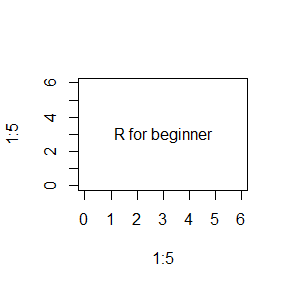

```r
plot(1:5, 1:5, xlim = c(0,6), ylim = c (0,6), type = "n")
text(x = 3, y = 3, labels = "R for beginner")
```

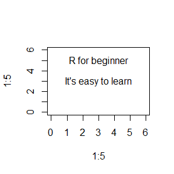

```r
plot(1:5, 1:5, xlim = c(0,6), ylim = c (0,6), type = "n")
text(x = c(3, 3), y = c(5,3), labels = c("R for beginner", "It's easy to learn"))
```

### Example 2

type = “p”: 绘制点，默认值  
type = “l”: 绘制线  
type = “b”: 同时绘制点和线  
type = “c”: 仅绘制参数“b”所示的线  
type = “o”: 同时绘制点和线，且线穿过点  
type = “h”: 绘制出点到横坐标轴的垂直线  
type = “s”: 绘制出阶梯图（先横后纵）  
type = “S”: 绘制出阶梯图（先纵后竖）  
type = “n”: 作空图

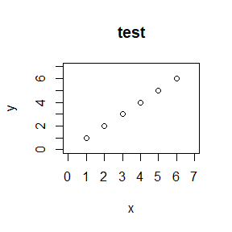

```r
x<- c(1:6)
y<- c(1:6)
plot(x,y,main="test",type="p",xlim = c(0,7),ylim = c(0,7))
```

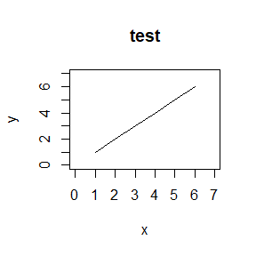

```r
x<- c(1:6)
y<- c(1:6)
plot(x,y,main="test",type="l",xlim = c(0,7),ylim = c(0,7))
```

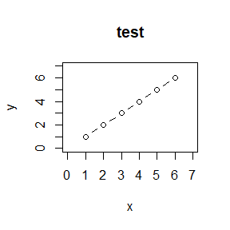

```r
x<- c(1:6)
y<- c(1:6)
plot(x,y,main="test",type="b",xlim = c(0,7),ylim = c(0,7))
```

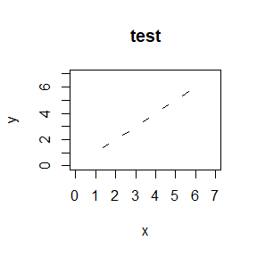

```r
x<- c(1:6)
y<- c(1:6)
plot(x,y,main="test",type="c",xlim = c(0,7),ylim = c(0,7))
```

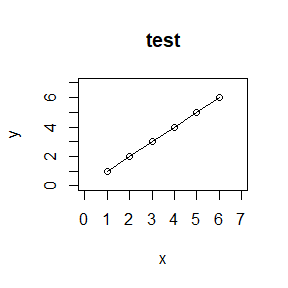

```r
x<- c(1:6)
y<- c(1:6)
plot(x,y,main="test",type="o",xlim = c(0,7),ylim = c(0,7))
```

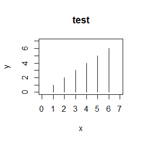

```r
x<- c(1:6)
y<- c(1:6)
plot(x,y,main="test",type="h",xlim = c(0,7),ylim = c(0,7))
```

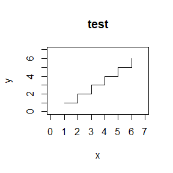

```r
x<- c(1:6)
y<- c(1:6)
plot(x,y,main="test",type="s",xlim = c(0,7),ylim = c(0,7))
```

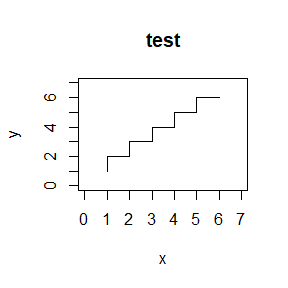

```r
x<- c(1:6)
y<- c(1:6)
plot(x,y,main="test",type="S",xlim = c(0,7),ylim = c(0,7))
```

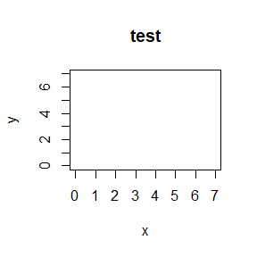

```r
x<- c(1:6)
y<- c(1:6)
plot(x,y,main="test",type="n",xlim = c(0,7),ylim = c(0,7))
```

### Example 3

绘制表格

| 姓名 | 学科 | 分数 |
| --- | --- | --- |
| 张三 | 英语 | 80 |
| 李四 | 语文 | 70 |
| 刘老师 | 物理 | 60 |

[output not shown]

## The homework 1 2021-09-23

### Question

Exercises 3.4, 3.11,3.20(page 94-96,Statistical Computating with R).

### Answer

#### 3.4:

The Rayleigh density [156, Ch. 18] is
$$f(x)=\frac{x}{\sigma^{2}} e^{-x^{2} /\left(2 \sigma^{2}\right)}, \quad x \geq 0, \sigma>0$$
Develop an algorithm to generate random samples from a Rayleigh(σ) distribution. Generate Rayleigh(σ) samples for several choices of σ > 0 and check that the mode of the generated samples is close to the theoretical mode σ (check the histogram).

解： 取 $\sigma=0.1$

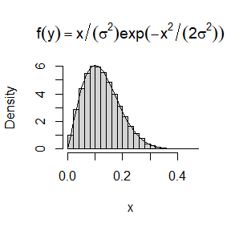

```r
rm(list=ls())
0.1->sigma;1e5->n;k<-1;numeric(n)->x
while (k<n) {
  runif(1)->u
  x[k]<-sqrt(2*log(1/u))*sigma; #广义均匀分布和单位均匀分布
  k+1->k
}
hist(x,prob=TRUE,main=expression(f(y)==x/(sigma^2)*exp(-x^2/(2*sigma^2))))
t<-seq(0,0.5,0.01)
lines(t,t/(sigma^2)*exp(-t^2/(2*sigma^2)))
```

取 $\sigma=1$

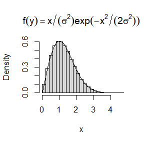

```r
rm(list=ls())
1->sigma;1e5->n;k<-1;numeric(n)->x
while (k<n) {
  runif(1)->u
  x[k]<-sqrt(2*log(1/u))*sigma; #广义均匀分布和单位均匀分布
  k <- k+1
}
hist(x,prob=TRUE,main=expression(f(y)==x/(sigma^2)*exp(-x^2/(2*sigma^2))))
t<-seq(0,6,0.01)
lines(t,t/(sigma^2)*exp(-t^2/(2*sigma^2)))
```

取 $\sigma=10$

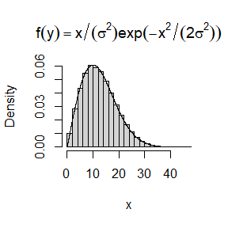

```r
rm(list=ls())
10->sigma;1e5->n;k<-1;numeric(n)->x
while (k<n) {
  runif(1)->u
  x[k]<-sqrt(2*log(1/u))*sigma; #广义均匀分布和单位均匀分布
  k <- k+1
}
hist(x,prob=TRUE,main=expression(f(y)==x/(sigma^2)*exp(-x^2/(2*sigma^2)),sigma==1))
t<-seq(0,40,0.01)
lines(t,t/(sigma^2)*exp(-t^2/(2*sigma^2)))
```

#### 3.11:

Generate a random sample of size 1000 from a normal location mixture. The components of the mixture have $N(0, 1)$ and $N(3, 1)$ distributions with mixing probabilities $p_1$ and $p_2 = 1 − p_1$. Graph the histogram of the sample with density superimposed, for $p_1 = 0.75$. Repeat with different values for $p_1$ and observe whether the empirical distribution of the mixture appears to be bimodal. Make a conjecture about the values of p1 that produce bimodal mixtures.

解：

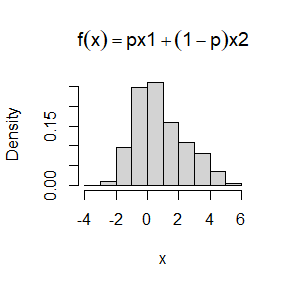

```r
rm(list=ls())
p<-0.75
n<-1e3;
x1<-rnorm(n,0,1)
x2<-rnorm(n,3,1)
x<-numeric(n)
k=1
while(k<n){
  u<-runif(1)
  if (u<=p) x[k]<-x1[k] else x[k]<-x2[k]
  k+1->k
}
hist(x,prob=TRUE,main=expression(f(x)==p*x1+(1-p)*x2))
```

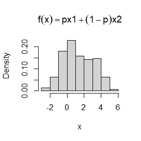

```r
rm(list=ls())
p<-0.6
n<-1e3;
x1<-rnorm(n,0,1)
x2<-rnorm(n,3,1)
x<-numeric(n)
k=1
while(k<n){
  u<-runif(1)
  if (u<=p) x[k]<-x1[k] else x[k]<-x2[k]
  k+1->k
}
hist(x,prob=TRUE,main=expression(f(x)==p*x1+(1-p)*x2))
```

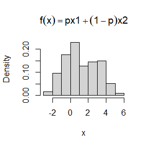

```r
rm(list=ls())
p<-0.55
n<-1e3
x1<-rnorm(n,0,1)
x2<-rnorm(n,3,1)
x<-numeric(n)
k=1
while(k<n){
  u<-runif(1)
  if (u<=p) x[k]<-x1[k] else x[k]<-x2[k]
  k+1->k
}
hist(x,prob=TRUE,main=expression(f(x)==p*x1+(1-p)*x2))
```

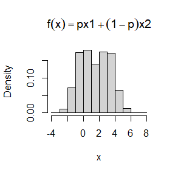

```r
rm(list=ls())
p<-0.5
n<-1e4;
x1<-rnorm(n,0,1)
x2<-rnorm(n,3,1)
x<-numeric(n)
k=1
while(k<n){
  u<-runif(1)
  if (u<=p) x[k]<-x1[k] else x[k]<-x2[k]
  k <- k+1
}
hist(x,prob=TRUE,main=expression(f(x)==p*x1+(1-p)*x2))
```

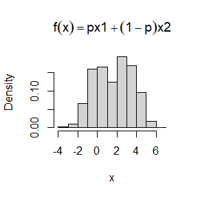

```r
rm(list=ls())
p<-0.45
n<-1e3;
x1<-rnorm(n,0,1)
x2<-rnorm(n,3,1)
x<-numeric(n)
k=1
while(k<n){
  u<-runif(1)
  if (u<=p) x[k]<-x1[k] else x[k]<-x2[k]
  k <- k+1
}
hist(x,prob=TRUE,main=expression(f(x)==p*x1+(1-p)*x2))
```

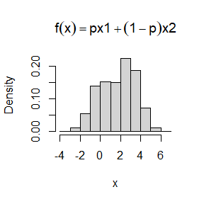

```r
rm(list=ls())
p<-0.4
n<-1e3;
x1<-rnorm(n,0,1)
x2<-rnorm(n,3,1)
x<-numeric(n)
k=1
while(k<n){
  u<-runif(1)
  if (u<=p) x[k]<-x1[k] else x[k]<-x2[k]
  k <- k+1
}
hist(x,prob=TRUE,main=expression(f(x)==p*x1+(1-p)*x2))
```

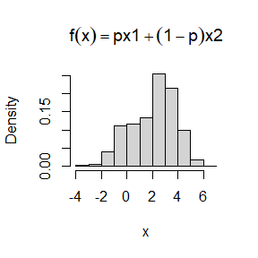

```r
rm(list=ls())
p<-0.35
n<-1e3;
x1<-rnorm(n,0,1)
x2<-rnorm(n,3,1)
x<-numeric(n)
k=1
while(k<n){
  u<-runif(1)
  if (u<=p) x[k]<-x1[k] else x[k]<-x2[k]
  k <- k+1
}
hist(x,prob=TRUE,main=expression(f(x)==p*x1+(1-p)*x2))
```

#### 3.20:

A compound Poisson process is a stochastic process $\{X(t), t ≥ 0\}$ that can be represented as the random sum $X(t) =\sum_{i=1}^{N(t)} Yi, t ≥ 0, where \{N(t), t ≥ 0\}$ is a Poisson process and $Y_1, Y_2,...$are $iid$ and independent of $\{N(t), t ≥ 0\}.$ Write a program to simulate a compound $Poisson(λ)–Gamma \ process (Y \ has \ a \ Gamma\ distribution)$. Estimate the mean and the variance of $X(10)$ for several choices of the parameters and compare with the theoretical values. Hint: Show that$E[X(t)] = λtE[Y1]$ and$Var(X(t)) = λtE[Y_1^{2}]$.

解：
${Y_i}$是Gamma分布，$N(t)$是泊松过程
In R, the Gamma distribution with parameters $shape = a$ and $scale = s$ has density
$$f(x)= \frac{1}{s^a\Gamma(a)} x^{a-1} e^{-x/s},\quad x\geq 0, a>0,s>0$$
You can use “rgamma(n,shape=a,scale=s)” to generate n gamma random numbers.

$$E[X]=\frac{\alpha}{\lambda}=as, \quad \operatorname{Var}(X)=\frac{\alpha}{\lambda^{2}}=as^2 \\
(E[X])^2 = a^2s^2, \quad E[X^2]= Var(X)+(E(X))^2=as^2+a^2s^2$$

泊松分布
$$P(X=k)=\frac{\lambda^k}{k!}e^{-\lambda},\quad k=0,1,...$$
泊松过程
$$P(X(t)=k)=\frac{(\lambda t)^k}{k!}e^{-\lambda t},\quad k=0,1,...$$
You can use “rpois(n,lambda)” to generate n Poison random numbers.
1) Generate n Poison distribution random numbers. 2) Generate n Gamma distribution random numbers. 3) 根据泊松分布的值Np(t)，对Y的前Np项进行求和作为X(t)的值

画出$Poisson(\lambda)-gamma\ process$

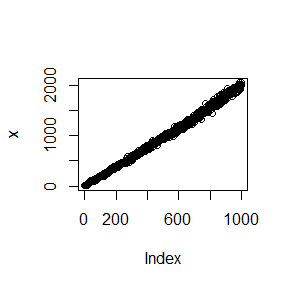

```r
rm(list=ls())
lambda.poison<-2
lambda.gamma<-1
a = 1
n<-1e3
Npoison<-numeric(n)
k<-1
while(k<=n){
  Npoison[k]<-rpois(1,lambda.poison*k)
  k <- k+1
}
maxp<- max(Npoison)
Y<-rgamma(maxp,shape = a,scale =1/lambda.gamma)
x<-numeric(n)
k<-1
while(k<=n){
  x[k]<-sum(Y[1:Npoison[k]])
  k+1->k
}
plot(x)
```

(1)对$X(10)$进行模拟计算

```r
rm(list=ls())
lambda.poison<-2
lambda.gamma<-1
a = 1
t=10
n<-1e4
k<-1
x<-numeric(n)
while(k<=n){
  Npoison<-rpois(1,lambda.poison*t)
  Y<-rgamma(Npoison,shape = a,scale =1/lambda.gamma)
  x[k]<-sum(Y[1:Npoison])
  k+1->k
}
paste('E[X(10)]=',mean(x))
```

```
#> [1] "E[X(10)]= 20.0962321463563"
```

```r
paste('Var(X(10)=',var(x))
```

```
#> [1] "Var(X(10)= 40.3663059325757"
```

理论计算值
$$E[X(t)]=\lambda t E[Y_1]=10\lambda a/\lambda_{gamma} \\
Var[x]=\lambda t E[Y_1^2]=10\lambda (a+a^2)/\lambda_{gamma}^2$$

```r
rm(list=ls())
lambda.poison<-2
lambda.gamma<-1
a = 1
Ex10<-10*lambda.poison*a/lambda.gamma
Var10<-10*lambda.poison*(a+a^2)/lambda.gamma^2
paste("E[X(10)]=",Ex10,",Var[X(10)]=",Var10)
```

```
#> [1] "E[X(10)]= 20 ,Var[X(10)]= 40"
```

(2)对$X(10)$进行模拟计算

```r
rm(list=ls())
lambda.poison<-2
lambda.gamma<-2
a = 1
t=10
n<-1e4
k<-1
x<-numeric(n)
while(k<=n){
  Npoison<-rpois(1,lambda.poison*t)
  Y<-rgamma(Npoison,shape = a,scale =1/lambda.gamma)
  x[k]<-sum(Y[1:Npoison])
  k+1->k
}
paste('E[X(10)]=',mean(x))
```

```
#> [1] "E[X(10)]= 10.003298514724"
```

```r
paste('Var(X(10)=',var(x))
```

```
#> [1] "Var(X(10)= 9.87564198808507"
```

理论计算值：
$$E[X(t)]=\lambda t E[Y_1]=10\lambda a/\lambda_{gamma} \\
Var[x]=\lambda t E[Y_1^2]=10\lambda (a+a^2)/\lambda_{gamma}^2$$

```r
rm(list=ls())
lambda.poison<-2
lambda.gamma<-2
a = 1
Ex10<-10*lambda.poison*a/lambda.gamma
Var10<-10*lambda.poison*(a+a^2)/lambda.gamma^2
paste("E[X(10)]=",Ex10,",Var[X(10)]=",Var10)
```

```
#> [1] "E[X(10)]= 10 ,Var[X(10)]= 10"
```

(3)对$X(10)$进行模拟计算

```r
rm(list=ls())
lambda.poison<-5
lambda.gamma<-4
a = 2
t=10
n<-1e4
k<-1
x<-numeric(n)
while(k<=n){
  Npoison<-rpois(1,lambda.poison*t)
  Y<-rgamma(Npoison,shape = a,scale =1/lambda.gamma)
  x[k]<-sum(Y[1:Npoison])
  k+1->k
}
paste('E[X(10)]=',mean(x),'Var(X(10)=',var(x))
```

```
#> [1] "E[X(10)]= 24.9834032696424 Var(X(10)= 18.603711546299"
```

理论计算值：
$$E[X(t)]=\lambda t E[Y_1]=10\lambda a/\lambda_{gamma} \\
Var[x]=\lambda t E[Y_1^2]=10\lambda (a+a^2)/\lambda_{gamma}^2$$

```r
rm(list=ls())
lambda.poison<-5
lambda.gamma<-4
a = 2
Ex10<-10*lambda.poison*a/lambda.gamma
Var10<-10*lambda.poison*(a+a^2)/lambda.gamma^2
paste("E[X(10)]=",Ex10,",Var[X(10)]=",Var10)
```

```
#> [1] "E[X(10)]= 25 ,Var[X(10)]= 18.75"
```

## The homework 2 2021-09-30

### Question

Exercises 5.4, 5.9, 5.13, and 5.14 (pages 149-151, Statistical Computating with R)

### Answer

#### 5.4

Write a function to compute a Monte Carlo estimate of the $\operatorname{Beta}(3,3)$ cdf, and use the function to estimate $F(x)$ for $x=0.1,0.2, \ldots, 0.9$. Compare the estimates with the values returned by the pbeta function in $R$.

解： $Beta(x;a,b)$分布的概率密度函数为
$$f(x;a,b)=\frac{1}{B(a,b)} x^{a-1}(1-x)^{b-1}$$
Beta函数定义：

$$B(a,b)=\int_{0}^{1} t^{a-1}(1-t)^{b-1} d t$$
$pbeta$的定义：
$$pbeta(x,a,b) =\frac{1}{B(a,b)} \int _0^x t^{a-1}(1-t)^{b-1}dt$$
$$B(3, 3)=\int_{0}^{1} t^{2}(1-t)^{2} d t$$
首先我们计算$B(3,3)$的积分估计
$$B(3,3)=\int_{0}^{1} t^{2}(1-t)^{2} d t=E[t^2(1-t)^2] , \quad t\sim U(0,1)$$
然后可以计算$pbeta(x,3,3)$的估计
$$pbeta(x,3,3) =\frac{1}{B(3,3)} \int _0^x t^{2}(1-t)^{2}dt = \frac{x}{B(3,3)}E[t^2(1-t)^2],\quad t\sim U(0,x)$$

```r
m<-1e4;x<-runif(m,min=0,max=1)
theta.hat <- mean(x^2*(1-x)^2)
result = matrix(0,1,2)
result[1,1] = theta.hat
result[1,2] = beta(3,3)
rownames(result) = c("Beta(3,3)")
colnames(result) = c("Estimate", "Theoretical")
result
```

```
#>             Estimate Theoretical
#> Beta(3,3) 0.03335882  0.03333333
```

编写求cdf的函数：

```r
rm(list=ls())

pbetaCDF <- function(x,a,b) {
  pbetax<-numeric(length(x))
  m<-1e6;
  y<-runif(m,min=0,max=1)
  Beta_a_b <- mean(y^(a-1)*(1-y)^(b-1))
  for(i in 1:length(x)){
    n<-1e6;
    y<-runif(n,min=0,max = x[i])
    Beta_x <- x[i]*mean(y^(a-1)*(1-y)^(b-1))
    pbetax[i] <- Beta_x/Beta_a_b
    }
  return(pbetax)
}
x<-seq(0.1,1,0.1)
y<-pbetaCDF(x,3,3)
print(y)
```

```
#>  [1] 0.008559487 0.058043110 0.163259059 0.317559830 0.500711878 0.682700566
#>  [7] 0.837815882 0.943223158 0.992557173 1.000230834
```

比较自定义函数和pbeta函数

```r
x<-seq(0.1,1,0.1)
result = matrix(0,3,length(x))
result[1,1:length(x)] = x
result[2,1:length(x)] = pbetaCDF(x,3,3)
result[3,1:length(x)] = pbeta(x,3,3)
rownames(result) = c("x","pbetaCDF(3,3)","pbeta(x,3,3)")
colnames(result) = c(x)
result
```

```
#>                       0.1        0.2       0.3       0.4       0.5       0.6
#> x             0.100000000 0.20000000 0.3000000 0.4000000 0.5000000 0.6000000
#> pbetaCDF(3,3) 0.008565376 0.05783268 0.1629428 0.3173322 0.4996883 0.6822389
#> pbeta(x,3,3)  0.008560000 0.05792000 0.1630800 0.3174400 0.5000000 0.6825600
#>                     0.7       0.8       0.9        1
#> x             0.7000000 0.8000000 0.9000000 1.000000
#> pbetaCDF(3,3) 0.8365465 0.9418508 0.9907868 1.000929
#> pbeta(x,3,3)  0.8369200 0.9420800 0.9914400 1.000000
```

#### 5.9

The Rayleigh density $[156,(18.76)]$ is
$$f(x)=\frac{x}{\sigma^{2}} e^{-x^{2} /\left(2 \sigma^{2}\right)}, \quad x \geq 0, \sigma>0$$
Implement a function to generate samples from a Rayleigh $(\sigma)$ distribution, using antithetic variables. What is the percent reduction in variance of $\frac{X+X^{\prime}}{2}$ compared with $\frac{X_{1}+X_{2}}{2}$ for independent $X_{1}, X_{2} ?$

解：
$$\begin{align}
& F(x) = \int_0^x \frac{t}{\sigma^{2}} e^{-t^{2} /\left(2 \sigma^{2}\right)}dt=1-e^{-x^2/{2\sigma^2}} \\
& y=1-e^{-x^2/{2\sigma^2}} \\
&\Rightarrow x =\sigma\sqrt{-2ln(1-y)} \\
& \Rightarrow x' =\sigma\sqrt{-2ln(y)} , \quad y\in[0,1]
\end{align}$$
因此方差
$$\begin{align}
E(X) &= \sigma^2\int_0^1 \sqrt{-2ln(1-y)}dy=\sqrt{\frac{\pi}{2}}\sigma \\
E(X') &= \sigma^2\int_0^1 \sqrt{-2ln(y)}dy=\sqrt{\frac{\pi}{2}}\sigma \\
Var(X) & = \sigma^2\int_0^1 (\sqrt{-2ln(1-y)}-\sqrt{\frac{\pi}{2}})^2dy = (2-\frac{\pi}{2})\sigma^2\\
Var(X') &= \sigma^2\int_0^1 (\sqrt{-2ln(y)}-\sqrt{\frac{\pi}{2}})^2dy =(2-\frac{\pi}{2})\sigma^2 \\
Cov(X,X') &= \sigma^2 \int_0^1 (\sqrt{-2ln(1-y)}-\sqrt{\frac{\pi}{2}})(\sqrt{-2ln(y)}-\sqrt{\frac{\pi}{2}})dy\\
Var(\frac{X+X'}{2}) &= (Var(X)+Var({X'})+2Cov(X,X'))/4 \\
&=1-\frac{\pi}{4}+\frac{1}{2}\sigma^2 \int_0^1 (\sqrt{-2ln(1-y)}-\sqrt{\frac{\pi}{2}})(\sqrt{-2ln(y)}-\sqrt{\frac{\pi}{2}})dy
\end{align}$$
两个独立的随机变量的方差
$$\begin{align}
Cov(X_1,X_2) &= 0 \\
Var(X_1) &= Var(X_2)=\sigma^2\int_0^1 (\sqrt{-2ln(1-y)}-\sqrt{\frac{\pi}{2}})^2dy = (2-\frac{\pi}{2})\sigma^2\\ \\
Var(\frac{X_1+X_2}{2}) &=(Var(X_1)+Var(X_2))/4 = 1-\frac{\pi}{4} \\
\end{align}$$
因此方差减小的百分比为
$$\begin{align}
Percent \ reduction &=\frac{(Var_x-Var_{x'})}{Var_x}\times 100\% \\
&=\frac{2}{\pi-4}\int_0^1 (\sqrt{-2ln(1-y)}-\sqrt{\frac{\pi}{2}})(\sqrt{-2ln(y)}-\sqrt{\frac{\pi}{2}})dy \times 100\% \\
\end{align}$$
(1)求协方差积分
$$\frac{1}{\sigma^2}Cov(X,X') = \int_0^1 (\sqrt{-2ln(1-y)}-\sqrt{\frac{\pi}{2}})(\sqrt{-2ln(y)}-\sqrt{\frac{\pi}{2}})dy$$

```
rm(list=ls())
m<-1e5;y<-runif(m)
covx12 <- mean((sqrt(-2*log(y))-sqrt(pi/2))*(sqrt(-2*log(1-y))-sqrt(pi/2)))
paste("Cov(X,X') = ",covx12)
```

```
rm(list=ls())
m<-1e5;y<-runif(m)
covx12 <- mean((sqrt(-2*log(y))-sqrt(pi/2))*(sqrt(-2*log(1-y))-sqrt(pi/2)))

result <-matrix(0,5,1)
result[1,1] <- 2-pi/2
result[2,1] <- covx12
result[3,1] <- 1-pi/4+1/2*covx12
result[4,1] <- 1-pi/4
result[5,1] <- paste("Percent reduction = ",2/(pi-4)*covx12*100,"%")
rownames(result) = c("Var(X) = ","Cov(X,X') = ","Var((X+X')/2) =","Var((X1+X2)/2) =","Percent reduction = ")
colnames(result) = c("理论计算值")
result
```

(3)实验上方差减小百分比

[output not shown]

#### 5.13

Find two importance functions $f_{1}$ and $f_{2}$ that are supported on $(1, \infty)$ and are ‘close’ to
$$g(x)=\frac{x^{2}}{\sqrt{2 \pi}} e^{-x^{2} / 2}, \quad x>1$$
Which of your two importance functions should produce the smaller variance in estimating
$$\int_{1}^{\infty} \frac{x^{2}}{\sqrt{2 \pi}} e^{-x^{2} / 2} d x$$
by importance sampling? Explain.

解
$$\begin{align}
\hat{\theta} &=\int_{1}^{\infty} \frac{x^{2}}{\sqrt{2 \pi}} e^{-x^{2} / 2} d x \\
& = \int_{1}^{\infty} \frac{g(x)}{f(x)}f(x)d x \\
& = \frac{1}{m} \sum_{i=1}^m \frac{g(x_i)}{f(x_i)}
\end{align}$$
取
$$\begin{align}
& let \quad f_1(x) =2exe^{-x^2} ,\quad f_2(x)=e^{-x+1} \\
& F_1(x)=1-e^{1-x^2},F_2(x)=1-e^{1-x}\\
& \frac{g(x)}{f_1(x)} = \frac{x}{2e\sqrt{2\pi}}e^{x^2/2} \\
& \frac{g(x)}{f_2(x)} = \frac{x^2}{\sqrt{2\pi}}e^{x-x^2/2-1}\\
&y_1=F_1(x_1) \Rightarrow x_1= \sqrt{1-ln(1-y_1)}=\sqrt{1-ln(y_1)}\\
&y_2=F_2(x_2) \Rightarrow x_2= 1-ln(1-y_2)=1-ln(y_2)
\end{align}$$

```r
rm(list=ls())
m<-1e5
y<-runif(m,min=0,max=1)
x1<-sqrt(1-log(y))
x2<-1-log(y)
f1<-x1/(2*exp(1)*sqrt(2*pi))*exp((x1^2)/2)
f2<-x2^2/(sqrt(2*pi))*exp(x2-(x2^2)/2-1)
result = matrix(0,2,2)
result[1,1] = mean(f1)
result[1,2] = mean(f1)
result[2,1] = sd(f1)
result[2,2] = sd(f2)
rownames(result) = c("est","sd")
colnames(result) = c("f1(x)","f2(x)")
result
```

```
#>        f1(x)     f2(x)
#> est 0.398450 0.3984500
#> sd  1.007925 0.1571454
```

Here ‘est’ is $\hat{\theta}$ while ‘sd’ is the standard deviation of $\frac{g(Xi )}{f (Xi )}$ instead of $\hat{\theta}$ So $f_2(x)=e^{-x+1}$ produce the smaller variance in estimating.

#### 5.14

Obtain a Monte Carlo estimate of
$$\int_{1}^{\infty} \frac{x^{2}}{\sqrt{2 \pi}} e^{-x^{2} / 2} d x$$
by importance sampling.

解： 和5.13中的方法一样，选取$f_2(x)=e^{-x+1}$
$$\begin{align}
& F(x)=1-e^{1-x}\\
& \frac{g(x)}{f(x)} = \frac{x^2}{\sqrt{2\pi}}e^{x-x^2/2-1}\\
&y=F(x_2) \Rightarrow x= 1-ln(1-y)=1-ln(y)
\end{align}$$

[output not shown]

## The homework 3 2021-10-14

### Question

Exercises 6.5 and 6.A (page 180-181, Statistical Computating with R).

### Answer

#### 6.5

Suppose a $95\%$ symmetric t-interval is applied to estimate a mean, but the sample data are non-normal. Then the probability that the confidence interval covers the mean is not necessarily equal to 0.95. Use a Monte Carlo experiment to estimate the coverage probability of the t-interval for random samples of $\chi^2_{2}$ data with sample size n = 20.  
Compare your t-interval results with the simulation results in Example 6.4. (The t-interval should be more robust to departures from normality than the interval for variance.)

解:
卡方分布密度
$$\begin{align}
\chi^2_n(x) &= \frac{1}{2^{n/2}\Gamma(n/2)} x^{n/2-1} e^{-x/2} ,\quad x>0 \\
E[X] & = n , \quad Var(X) = 2n \\
Z_1 \sim \chi^2_{n1},&Z_2 \sim \chi^2_{n2} \Rightarrow Z_1+Z_2 \sim \chi^2_{n_1+n_2}
\end{align}$$

$$\begin{align}
&if \quad X \sim N(0,1),Y_i \sim \chi_n^2 \quad and \quad X,Y_i \quad independent \\
&\Rightarrow T=\frac{X}{\sqrt{Y_i/n}} \sim t_n \\
&\Rightarrow \sum_{i=1}^m Y_i \sim \chi_{m*n}^2 \\
&\Rightarrow T=\frac{X}{\sqrt{\sum_{i=1}^m Y_i/(n*m)}} \sim t_{n*m} \\
&\Rightarrow T=\frac{X}{\sqrt{\bar{Y}/n}} \sim t_{n*m} \\
\end{align}$$

$$\begin{align}
x_1,x_2,...x_n \sim N(0,1) \\
T = \frac{\bar{X}-\mu}{S_n/\sqrt{n}} \sim t_{n-1}
\end{align}$$

```r
rm(list = ls())
m <- 20
n <- 2
alpha <- 0.05
Y <- rchisq(m,n)
a<-t.test(Y,conf.level = 1-alpha)
paste('均值的 95%t-interval:',a[4])
```

```
#> [1] "均值的 95%t-interval: c(1.28239095997856, 3.93343943744651)"
```

```r
UCL <- (m-1)*var(Y)/qchisq(alpha,df=m-1)
paste('upper confidence limits UCL =',UCL)
```

```
#> [1] "upper confidence limits UCL = 15.0646204479727"
```

```r
rm(list= ls())
m <- 20
n <- 2
alpha <- .05
mu0 = n
x <- rchisq(m, df = n)
LCL <- mu0+var(x)*qt(alpha/2, df = m-1)/sqrt(m)
UCL <- mu0+var(x)*qt(1-alpha/2, df = m-1)/sqrt(m)
paste('均值的 95%t-interval:[',LCL,',',UCL,']')
```

```
#> [1] "均值的 95%t-interval:[ 0.0359161395378311 , 3.96408386046217 ]"
```

MC实验 t-interval 包含了均值$\mu = 2$  
A two sides $100(1−\alpha)\%$ confidence interval of variance is given by $\mu+\frac{S_n}{\sqrt{n}}t_{n-1}(\alpha/2),\mu+\frac{S_n}{\sqrt{n}}t_{n-1}(1-\alpha/2)$

#### 6.A

Use Monte Carlo simulation to investigate whether the empirical Type I error rate of the t-test is approximately equal to the nominal significance level $\alpha$, when the sampled population is non-normal. The t-test is robust to mild departures from normality. Discuss the simulation results for the cases where the sampled population is (i) $\chi^2_{1}$ (ii) Uniform(0,2) (iii) Exponential(rate=1).  
In each case, test $H_0 : \mu = \mu_0 \quad vs \quad H_1 : \mu \neq \mu_0$, where $\mu_0$ is the mean of $\chi^2_{1}$, Uniform(0,2), and Exponential(1), respectively.  
解: 单样本t检验，适用于样本均值与总体均值的比较，是检验样本均值所代表的的总体均值是否与理论值有差别

I 型错误率是$H_0$正确，但是推翻$H_0$接受$H_1$的概率是$\alpha$ $E[\chi_1^2] = E[u(0,2)] =E[E(1))]= 1$  
则检验问题变成 $H_0 : \mu = 1 \quad vs \quad H_1 : \mu \neq 1$ $t1e = \frac{1}{m}\sum_{j=1}^m I(p_j \leq \alpha)$

$T^* = \frac{\bar{X}-\mu_0}{S/\sqrt{n}} \sim t(n-1)$  
(1)

[output not shown]

```
rm(list=ls())
m <- 1e3 ##实验次数
n <- c(1e1,1e2,5*1e2,1e3,5*1e3,1e4,2*1e4,3*1e4,4*1e4,5*1e4,6*1e4,1e5) ##每次实验的样本数
alpha <- 0.05
mu0 <- 1
p.hat <- numeric(length(n))
se.hat <- numeric(length(n))

for (i in 1:length(n)){
  p <- numeric(m)  #存储 p-values
  for (j in 1:m){
    k <- n[i]
    x <- rchisq(k,df = 1)
    ttest <- t.test(x,alternative = "two.sided",mu = mu0,conf.level =1- alpha)
    p[j] <- ttest$p.value
}
  p.hat[i] <- mean(p < alpha)
  se.hat[i] <- sqrt(p.hat[i] * (1 - p.hat[i]) / m)
}
plot(n,p.hat/alpha)
```

```
rm(list=ls())
m <- 1e4 ##实验次数
n <- 1e3 ##每次实验的样本数
alpha <- 0.05
mu0 <- 1

p <- numeric(m)  #存储 p-values
for (j in 1:m){
  x <- runif(n,0,2)
  ttest <- t.test(x,alternative = "two.sided",mu = mu0,conf.level =1- alpha)
  p[j] <- ttest$p.value
}
p.hat <- mean(p < alpha)
se.hat <- sqrt(p.hat * (1 - p.hat) / m)
print(c(p.hat, se.hat))
```

```
rm(list=ls())
m <- 1e4 ##实验次数
n <- 1e3 ##每次实验的样本数
alpha <- 0.05
mu0 <- 1

p <- numeric(m)  #存储 p-values
for (j in 1:m){
  x <- rexp(n,rate =1)
  ttest <- t.test(x,alternative = "two.sided",mu = mu0,conf.level =1- alpha)
  p[j] <- ttest$p.value
}
p.hat <- mean(p < alpha)
se.hat <- sqrt(p.hat * (1 - p.hat) / m)
print(c(p.hat, se.hat))
```

#### Supplement

If we obtain the powers for two methods under a particular simulation setting with 10,000 experiments: say, 0.651 for one method and 0.676 for another method. We want to know if the powers are different at 0.05 level.  
(1)What is the corresponding hypothesis test problem?  
(2)What test should we use? Z-test, two-sample t-test, paired-t test or McNemar test? Why?  
(3)Please provide the least necessary information for hypothesis testing.

解:检验的Power:$\pi(\theta)=1-\beta$是在知道参数真值为$\theta$时,拒绝$H_0$的概率,II型错误率是$1-\pi(\theta)$功效分析是在知道：显著性水平，功效，效应值，样本大小,三者中任意三个值，求另一个值  
(1) $H_0: 方法1和方法2的power相同 \leftrightarrow H_{\alpha}:方法1和方法2的power不同 \neq 0$  
(2) McNemar,用来比较两种方法是否有显著性差异 $\tau_{\chi^2}=\frac{(|Power_1-Power_2|-1)^2}{Power_1+Power_2} \sim \chi_1^2$

```
p1 <- 0.651
p2 <- 0.676
alpha <- 0.05
tau <- (abs(p1-p2)-1)^2/(p1+p2)
xi <- qchisq(1-alpha,df =1)
print(c(tau,xi))
```

[output not shown]

## The homework 5 2021-10-28

### Question

Exercises 7.7, 7.8, 7.9, and 7.B (pages 213, Statistical Computating with R)

### Answer

#### 7.7

Refer to Exercise 7.6. Efron and Tibshirani discuss the following example [84, Ch. 7]. The five-dimensional scores data have a $5 \times 5$ covariance matrix $\Sigma$, with positive eigenvalues $\lambda_{1}>\cdots>\lambda_{5} .$ In principal components analysis,
$$\theta=\frac{\lambda_{1}}{\sum_{j=1}^{5} \lambda_{j}}$$
measures the proportion of variance explained by the first principal component. Let $\hat{\lambda}_{1}>\cdots>\hat{\lambda}_{5}$ be the eigenvalues of $\hat{\Sigma}$, where $\hat{\Sigma}$ is the $\mathrm{MLE}$ of $\Sigma$. Compute the sample estimate
$$\hat{\theta}=\frac{\hat{\lambda}_{1}}{\sum_{j=1}^{5} \hat{\lambda}_{j}}$$
of $\theta$. Use bootstrap to estimate the bias and standard error of $\hat{\theta}$.

#### Solution

```
rm(list = ls())
library(knitr)
library(bootstrap) #for the law data

score <- matrix(0,length(scor$mec),5)  # 88*5
score[,1] <- scor$mec
score[,2] <- scor$vec
score[,3] <- scor$alg
score[,4] <- scor$ana
score[,5] <- scor$sta

n <- length(scor$mec)
xigma.hat <- cov(score)
xigma.ev <-eigen(xigma.hat)
xigma.lambda <- xigma.ev$values
theta.hat <- xigma.lambda[1]/sum(xigma.lambda)

B <- 5000
theta.b <-numeric(B)
for (b in 1:B){
  i<- sample(1:n,size = n,replace = TRUE)
  xigma0.hat <- cov(score[i,])
  xigma0.ev <- eigen(xigma0.hat)
  xigma0.lambda <- xigma0.ev$values
  theta.b[b] <- xigma0.lambda[1]/sum(xigma0.lambda)
}
bias <- mean(theta.b)-theta.hat
se.theta <- B/(B-1)*var(theta.b)
boot.theta.hat <- mean(theta.b)
standard.error <- sqrt(se.theta)

result <- cbind(theta.hat, boot.theta.hat, bias,standard.error)#合并计算结果
dimnames(result)[[2]] <- c("theta", "Bootstrap theta.hat", "bias", "standard error")#重命名各列
kable(result, caption = "表1：用bootstrap估计theta.hat的bias和standard error") #利用kable绘制计算结
```

#### 7.8

Refer to Exercise 7.7. Obtain the jackknife estimates of bias and standard error of $\hat{\theta}$.

#### Solution

```
rm(list = ls())
library(bootstrap) #for the law data
library(knitr)

score <- matrix(0,length(scor$mec),5)  # 88*5
score[,1] <- scor$mec
score[,2] <- scor$vec
score[,3] <- scor$alg
score[,4] <- scor$ana
score[,5] <- scor$sta

n <- length(scor$mec)
xigma.hat <- cov(score)
xigma.ev <-eigen(xigma.hat)
xigma.lambda <- xigma.ev$values
theta.hat <- xigma.lambda[1]/sum(xigma.lambda)

theta.jack <-numeric(n)

for (i in 1:n){
  xigma0.hat <- cov(score[-i,])  #Jackknife
  xigma0.ev <- eigen(xigma0.hat)
  xigma0.lambda <- xigma0.ev$values
  theta.jack[i] <- xigma0.lambda[1]/sum(xigma0.lambda)
}
bias.jack <- (n-1)*(mean(theta.jack)-theta.hat)
bias.se <- sqrt((n-1)*mean(theta.jack-mean(theta.jack))^2)


jack.theta.hat <- mean(theta.jack)
standard.error <- sd(theta.jack)

result <- cbind(theta.hat, jack.theta.hat, bias.jack,standard.error)#合并计算结果
dimnames(result)[[2]] <- c("theta", "Jackknife theta.hat", "bias", "standard error")#重命名各列
kable(result, caption = "表2：用Jackknife估计theta.hat的bias和standard error") #利用kable绘制计算结
```

#### 7.9

Refer to Exercise 7.7. Compute 95% percentile and BCa confidence intervals for $\hat{\theta}$. #### Solution

```
rm(list = ls())
library(knitr)
library(bootstrap) #for the law data
level <- 0.95

boot.se <- function(X,R,f){
  #local function to compute the bootstrap
  #estimate of standard error for statistic f(x)
  x <- as.matrix(x); m <- nrow(x)
  th <- replicate(R, expr = {
  i <- sample(1:m, size = m, replace = TRUE)
  f(x[i, ])
  })
  return(sd(th))
}

score <- matrix(0,length(scor$mec),5)  # 88*5
score[,1] <- scor$mec
score[,2] <- scor$vec
score[,3] <- scor$alg
score[,4] <- scor$ana
score[,5] <- scor$sta

n <- length(scor$mec)
xigma.hat <- cov(score)
xigma.ev <-eigen(xigma.hat)
xigma.lambda <- xigma.ev$values
theta.hat <- xigma.lambda[1]/sum(xigma.lambda)

B <- 5000  #计算bootstrp的次数
R <- 100 ##计算标准差的次数
theta.b <-numeric(B)
se <- numeric(B)

statistic <-function(x){
  xigma0.hat <- cov(x)
  xigma0.ev <- eigen(xigma0.hat)
  xigma0.lambda <- xigma0.ev$values
  return(xigma0.lambda[1]/sum(xigma0.lambda))
}

for (b in 1:B){
  i<- sample(1:n,size = n,replace = TRUE)
  boostrapscore <- score[i,]
  xigma0.hat <- cov(boostrapscore)

  th <- replicate(R,expr={
    j<- sample(1:n,size = n,replace = TRUE)
    statistic(boostrapscore[j,])
  })
  xigma0.ev <- eigen(xigma0.hat)
  xigma0.lambda <- xigma0.ev$values
  theta.b[b] <- xigma0.lambda[1]/sum(xigma0.lambda)
  se[b] <- sd(th)
}


bias <- mean(theta.b)-theta.hat
se.theta <- B/(B-1)*var(theta.b)
boot.theta.hat <- mean(theta.b)
standard.error <- sqrt(se.theta)

stat0 <- statistic(score)
stat <- theta.b
se0 <- sd(stat)
t.stats <- (stat-stat0)/se
alpha <- 1-level

Qt <- quantile(t.stats,c(alpha/2,1-alpha/2),type=1)
names(Qt) <- rev(names(Qt))
CI <- rev(stat0-Qt*se0)
CI
```

#### 7.B

Repeat Project 7.A for the sample skewness statistic. Compare the coverage rates for normal populations (skewness 0) and $\chi^2_5$ distributions (positive skewness).

#### Solution

```
rm(list = ls())
n <- 1000  #样本数量
alpha <- 0.05
B <- 200  #bootstrap 次数

sk <- function(xs) {

  # 计算统计值
  sample.skewness <- function (sample) {
    mu <- mean(sample)
    n <- length(sample)
    num <- 1/n * sum(sapply(sample, function (x) (x - mu)^3))
    denom <- sd(sample)^3
    return (num/denom)
  }

  theta.hat <- sample.skewness(xs)


  theta.hat.b <- numeric(B)

  for (b in 1:B) {
    i <- sample(1:n, n, TRUE)
    xs.b <- xs[i]
    theta.hat.b[b] <- sample.skewness(xs.b)
  }

  sd.hat <- sd(theta.hat.b)

  # 可视化
  par(mfrow = c(1, 1))
  hist(theta.hat.b)

  # 置信区间

  probs <- c(alpha/2, 1-alpha/2)
  names <- sapply(probs, function(p) paste(p*100, '%', sep <- ''))
  qs.theta.hat.b <- quantile(theta.hat.b, probs)

  # 标准正态区间
```

[output cut: 31 more lines]

```
  ci.data$left.miss <- ci.data$left.miss/rep
  ci.data$right.miss <- ci.data$right.miss/rep

  return(ci.data)
}

df <- 5
x1 <- rchisq(n, df = df)
sk(x1)

sd <- sd(x1)
mux <- mean(x1)
x2 <- rnorm(n, mean = mux, sd = sd)

sk(x2)
```

[output not shown]

## The homework 7 2021-11-11

### Question

Exercies 9.3 and 9.8 (pages 277-278, Statistical Computating with R)

### Answer

#### 9.3

Use the Metropolis-Hastings sampler to generate random variables from a standard Cauchy distribution. Discard the first 1000 of the chain, and compare the deciles of the generated observations with the deciles of the standard Cauchy distribution (see qcauchy or qt with df=1). Recall that a $Cauchy(θ, η)$ distribution has density function
$$f(x) = \frac{1}{\theta\pi(1+[(x-\eta)/\theta]^2)}, -\infty<x<\infty,\theta>0$$
#### Solution

```
rm(list = ls())
library(knitr)
# Causcht(theta,eta)
set.seed(1145140)

Gelman.Rubin <- function(psi) {
  # psi[i,j] 是 检验函数 psi(X[i,1:j])的值
  # X的第i行为第i条链
  psi <- as.matrix(psi)
  n <- ncol(psi)
  k <- nrow(psi)
  psi.means <- rowMeans(psi) #所有行的平均值，链之间的平均
  B <- n * var(psi.means) # 链之间的方差估计
  psi.w <- apply(psi, 1, "var") #within variances
  W <- mean(psi.w) #within est.
  v.hat <- W*(n-1)/n + (B/n) #upper variance est.
  r.hat <- v.hat / W #G-R statistic
  return(r.hat)
}

normal.chain<-function(N,theta,eta,X1){
  x <- numeric(N)
  x[1] <- X1
  k <- 0
  u <- runif(N)
  for (i in 2:N) {
  xt <- x[i-1]
  y <- rnorm(1, xt)
  shang <- df(y,theta=theta, eta=eta) * dnorm(xt, y)
  xia <- df(xt, theta=theta, eta=eta) * dnorm(y, xt)
  if (u[i] <= shang/xia) x[i] <- y

  else {
    x[i] <- xt
    k <- k+1 #y 被拒绝
    }
  }
  return(x)
}


df <- function(x,theta,eta) {
  stopifnot(theta > 0)
  return(1 /(theta*pi*(1+((x-eta)/theta)^2) ))
}

m <- 10000  #样本长度
b <- 1000 #去掉的长度
theta <- 1
eta <- 0
burn <- 1000


x0 <- c(-10,-5,1,2,5,10,15,20)  #设置初始值
K <- length(x0)

#产生链
X <- matrix(0,nrow = K,ncol=m)
for (i in 1:K){
  X[i,] <- normal.chain(m,theta,eta,x0[i])

}


index <- burn+1:m
# 选择第3条链来进行绘图
xx <- X[3,]
y1 <- xx[index]  #产生的MCMC

y2 <- rcauchy(length(y1), location = 0, scale = 1)  #cauchy产生的
par(mfrow = c(1,2))
plot(index, y1,type="l",main="去掉前面1000个样本后的M-H链", ylab="X")
hist(y1, probability = TRUE, breaks = 100,main="密度分布图",xlab="X")

plot.y1 <- seq(min(xx), max(xx), 0.01)
lines(plot.y1, df(plot.y1,theta=theta, eta=eta),main="密度分布图",xlab="X")
par(mfrow = c(1,1))

#psi <- t(apply(X, 1, cumsum))
#for (i in 1:nrow(psi)) psi[i,] <- psi[i,] / (1:ncol(psi))

paste("R=",Gelman.Rubin(X))


rhat <- rep(0, m)
for (j in (b+1):m){
  rhat[j] <- Gelman.Rubin(X[,1:j])
}
plot(rhat[(b+1):m], main = bquote(R),type="l", xlab="", ylab="R")
abline(h=1.1, lty=2)

## 计算分位数

qmh <- c(1:K)
qcau <- c(1:K)
for (i in 1:K){
  qmh[i] <- quantile(X[i,],c(0.1))
  qcau[i] <- qcauchy(0.1, 0,1)
}
result <- cbind(qmh,qcau)  #合并计算结果
dimnames(result)[[2]] <- c("M-H 10%分位数", "标准柯西10%分位数") #重命名各列
kable(result, caption = "分位数对比")
```

#### 9.8

This example appears in [40]. Consider the bivariate density
$$f(x,y) \propto \left( \begin{array}{c} n \\ x \end{array} \right) y^{x+a-1}(1-y)^{n-x+b-1} , x=0,1,...,n, 0\leq y\leq 1$$
It can be shown (see e.g. [23]) that for fixed a, b, n, the conditional distributions are $Binomial(n, y)$ and $Beta(x+ a, n−x+ b)$. Use the Gibbs sampler to generate a chain with target joint density $f(x, y)$

#### Solution

$$f(X|Y) = Binomial(n,y) = \left( \begin{array}{c} n \\ x \end{array} \right) y^{x}(1-y)^{n-x} \\
E[X|Y] = ny \\
f(Y|X) = Beta(x+a,n-x+b) = \frac{\Gamma(a+n+b)}{\Gamma(x+a)\Gamma(n-x+b)}y^{x+a-1}(1-y)^{n-x+b-1} \\
E[Y|X] = \frac{x+a}{n+a+b}\\$$

```
N <- 5000 #链的长度
burn <- 1000 #burn-in length

###### Mode Parameter #####
n <- 50
a <- 1
b <- 2

###### 产生链的函数 #####
bivariate.chain <- function(N,n,a,b,X1,Y1){
  # N个数据点 参数 n,a,b,初值 X1,Y1
  data <- list(X = matrix(0,1,N),Y=matrix(0,1,N)) #the chain, a bivariate sample
  data$X[1] <- X1
  data$Y[1] <- Y1
  for ( i in 2:N){
    x2 <- data$Y[i-1]
    data$X[i] <- rbinom(1, n, x2)
    x1 <- data$X[i]
    data$Y[i] <- rbeta(1,x1+a,n-x1+b)
  }
  return(data)
}



#每条链的初始值
x0 <- c(1,5,10,15,20,50,100)
y0 <- c(0.01,0.05,0.1,0.2,0.5,0.7,0.9)
K <- length(x0)  #几条链

#产生链
X <- matrix(0,K,N)
Y <- matrix(0,K,N)
for (i in 1:K){
  data <- bivariate.chain(N,n,a,b,x0[i],y0[i])
  X[i,] <- data$X
  Y[i,] <- data$Y
}



bs <- burn+1
index <- (burn+1):N
x <- X[1,index]
y <- Y[1,index]


plot(t(rbind(x,y)), main="联合密度分布图", cex=.5, xlab="X",ylab="Y", ylim=range(y))

#产生的MCMC

par(mfrow = c(1,2))
plot(index, x,type="l",main="X的去掉前面1000个样本后的Gibbs链", ylab="X")
hist(x, probability = TRUE, breaks = 100,main="密度分布图",xlab="X")
par(mfrow = c(1,1))

par(mfrow = c(1,2))
plot(index, y,type="l",main="Y的去掉前面1000个样本后的Gibbs链", ylab="Y")
hist(y, probability = TRUE, breaks = 100,main="密度分布图",xlab="Y")
par(mfrow = c(1,1))
paste("Rx=",Gelman.Rubin(X))
paste("Ry=",Gelman.Rubin(Y))

#plot the sequence of R-hat statistics
rhat <- rep(0, N)
for (j in (b+1):N){
  rhat[j] <- Gelman.Rubin(X[,1:j])
}
plot(rhat[bs:N], type="l", xlab="", ylab="R")
abline(h=1.1, lty=2)


rhat <- rep(0, N)
for (j in (b+1):N){
  rhat[j] <- Gelman.Rubin(Y[,1:j])
}
plot(rhat[bs:N], type="l", xlab="", ylab="R")
abline(h=1.1, lty=2)
```

#### Supplement

For each of the above exercise, use the Gelman-Rubin method to monitor convergence of the chain, and run the chain until it converges approximately to the target distribution according to $\hat{R} < 1.2$

#### Solution

[output not shown]

## The homework 9 2021-11-25

## Question

Exercises 1 and 5 (page 204, Advanced R) Excecises 1 and 7 (page 214, Advanced R)

## Answer

#### 11.1.2.1

Why are the following two invocations of lapply() equivalent?

```r
set.seed(12315)
trims <- c(0, 0.1, 0.2, 0.5)
x <- rcauchy(100)

lapply(trims, function(trim) mean(x, trim = trim))
```

```
#> [[1]]
#> [1] -3.520485
#>
#> [[2]]
#> [1] 0.3194412
#>
#> [[3]]
#> [1] 0.2229875
#>
#> [[4]]
#> [1] 0.2166389
```

```r
lapply(trims, mean, x = x)
```

```
#> [[1]]
#> [1] -3.520485
#>
#> [[2]]
#> [1] 0.3194412
#>
#> [[3]]
#> [1] 0.2229875
#>
#> [[4]]
#> [1] 0.2166389
```

因为$lapply(X,FUN,其他参数)$是返回一个与X长度相同的列表，飞哥元素都是将函数FUN作用应用于X的响应元素的结果 $mean(x,trim = ,na.rm = FALSE,...)$ 其中x是数值向量，仅仅当$trim=0$时，复数向量才可以 $trim$是$[0,0.5]$的比例系数 在计算均值之前，从x的两端去掉观测值的比例$(0\sim 0.5)$ 在 $lapply(trims, function(trim) mean(x, trim = trim))$中 函数$mean$计算去掉两端trim的比例 ,其实 写成$lapply(trims, function(trim) mean(x, trim))$ 结果是一样的 trim放在mean的参数列表前面，后面就要指定$x=data$即$mean(trim,x=x)$ trim放在mean的参数列表后面，可以直接写成$mean(x,trim)

```r
lapply(trims, function(trim) mean(x,trim))
```

```
#> [[1]]
#> [1] -3.520485
#>
#> [[2]]
#> [1] 0.3194412
#>
#> [[3]]
#> [1] 0.2229875
#>
#> [[4]]
#> [1] 0.2166389
```

#### 11.1.2.5

For each model in the previous two exercises, extract $R^2$ using the function below.

```yaml
rsq <- function(mod) summary(mod)$r.squared
```

1. Use both for loops and lapply() to fit linear models to the mtcars using the formulas stored in this list:

```r
rm(list=ls())

formulas <- list(
mpg ~ disp,
mpg ~ I(1/disp),
mpg ~ disp + wt,
mpg ~ I(1/disp) + wt
)

boot_df <- function(x){
  return(x[sample(nrow(x), replace = TRUE), ])
}

rsq <- function(mod) {
  summary(mod)$r.squared
}

boot_lm <- function(formu){
  dat <- boot_df(mtcars)
  rsq(lm(formu,data = dat))
}
#用lapply()
#lapply(formulas,lm,data = boot_df(mtcars))

lapply(formulas,boot_lm)
```

```
#> [[1]]
#> [1] 0.713614
#>
#> [[2]]
#> [1] 0.8332219
#>
#> [[3]]
#> [1] 0.7862372
#>
#> [[4]]
#> [1] 0.9033778
```

```r
#用for

for (i in 1:length(formulas)){
  print(boot_lm(formulas[[i]]))
}
```

```
#> [1] 0.7077747
#> [1] 0.8725245
#> [1] 0.7980984
#> [1] 0.847342
```

```r
#因为用了boot_strap所以两个结果不一样
```

2. Fit the model mpg ~ disp to each of the bootstrap replicates of mtcars in the list below by using a for loop and lapply(). Can you do it without an anonymous function?

```r
bootstraps <- lapply(1:10, function(i) {
rows <- sample(1:nrow(mtcars), rep = TRUE)
mtcars[rows, ]
})

boot_mpg_disp <- function(dat){
  rsq(lm(mpg~disp,data = boot_df(dat)))
}
#使用lapply
lapply(bootstraps, boot_mpg_disp)
```

```
#> [[1]]
#> [1] 0.6577088
#>
#> [[2]]
#> [1] 0.6720489
#>
#> [[3]]
#> [1] 0.8279625
#>
#> [[4]]
#> [1] 0.7219773
#>
#> [[5]]
#> [1] 0.82747
#>
#> [[6]]
#> [1] 0.6864452
#>
#> [[7]]
#> [1] 0.7065602
#>
#> [[8]]
#> [1] 0.7104219
#>
#> [[9]]
#> [1] 0.8389606
#>
#> [[10]]
#> [1] 0.7787436
```

```r
#使用for循环
for (i in 1:length(bootstraps)){
  dat <- boot_df(bootstraps[[i]])
  print(rsq(lm(mpg~disp,data = dat)))
}
```

```
#> [1] 0.6281573
#> [1] 0.6323042
#> [1] 0.8513368
#> [1] 0.685374
#> [1] 0.7451628
#> [1] 0.5596998
#> [1] 0.6752615
#> [1] 0.6448476
#> [1] 0.7364718
#> [1] 0.7855587
```

#### 11.2.5.1

Use vapply() to: a) Compute the standard deviation of every column in a numeric data frame. b) Compute the standard deviation of every numeric column in a mixed data frame. (Hint: you’ll need to use vapply() twice.)

```r
n <- 100
df <- data.frame(x = 1:n, y = rnorm(n,0,1))
vapply(df,sd,c(1))
```

```
#>          x          y
#> 29.0114920  0.9495975
```

```r
n <- 100
df <- data.frame(x = rchisq(n,1), y = letters[1:10],z = rnorm(n,0,1))

vapply(df,function(dat){
  if(is.numeric(dat)==TRUE){
    return(sd(dat))
  }
  else{
    return(NA)
  }
},c(1.2))
```

```
#>        x        y        z
#> 1.355592       NA 1.032777
```

```r
#a <- vapply(df, class, character(1)) == "numeric"
#vapply(df,sd,c(1))
```

#### 11.2.5.7

Implement mcsapply(), a multicore version of sapply(). Can you implement mcvapply(), a parallel version of vapply()? Why or why not?

```
library(parallel)
#detectCores函数可以告诉你你的CPU可使用的核数
detectCores()

mcsapply <-function(x,Fun,...){
  #cores 指定计算核的数量
  mc <- getOption("mc.cores", detectCores() )
  res <- mclapply(x, fun, mc.cores = mc);
  return(res)
}


mcvapply <-function(x,Fun,cha,cores =4,...){
  #cha指定返回的类型
  mc <- getOption("mc.cores", detectCores() )
  res <- mclapply(x, fun, mc.cores = mc);
  return(res)
}

n <- 100
df <- data.frame(x = 1:n, y = rnorm(n,0,1))
mcsapply(df,sd)
```

Windows上跑不了mc.cores

[output not shown]